# R Notebook

```r
library(mongolite)
library(arules)
library(arulesViz)
library(sqldf)
library(RColorBrewer)
```

#obtener datos de mongodb

```r
tweets <- mongo(collection = "tweets_tp2", db = "DMUBA")

df_tweets = tweets$find()

nrow(df_tweets)
```

```
[1] 327961
```

##se calcula por cada tweet retweeteado, #el tiempo entre la creacion de tweet y su primer RT –>tiempo_primera_rpta_RT #el tiempo entre el primer RT y el ultimo RT —> duracion_RT # el max de retweet_favorite_count para el tweet RT —>adhesion_RT # el max de retweet_retweet_count para el tweet RT —->difusion_RT #cantidad de RT #en minutos y horas

```r
stringsqla = "select retweet_status_id,(min(created_at) - retweet_created_at)/60 as tiempo_primera_rpta_RT_min,(min(created_at) - retweet_created_at)/3600 as tiempo_primera_rpta_RT_hs, (max(created_at) - min(created_at))/60 as duracion_RT_min,(max(created_at) - min(created_at))/3600 as duracion_RT_hs, max(retweet_favorite_count) as adhesion_RT, max(retweet_retweet_count) as difusion_RT,count(*) as cant_RT from df_tweets group by retweet_status_id"

df_tweets_tot = sqldf(stringsqla)

nrow(df_tweets_tot)
```

```
[1] 96388
```

#1 difusion #se agrega una columna on el valor de log10

```r
df_tweets_tot$difusion_RTlog10 = log10(df_tweets_tot$difusion_RT)
```

#histogramas de analisis

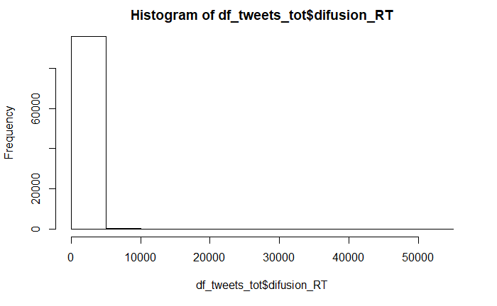

```r
hist(df_tweets_tot$difusion_RT)
```

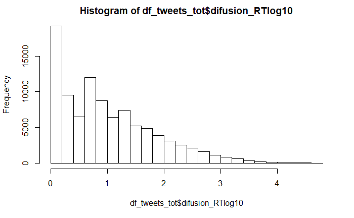

```r
hist(df_tweets_tot$difusion_RTlog10)
```

#categorias de difusion

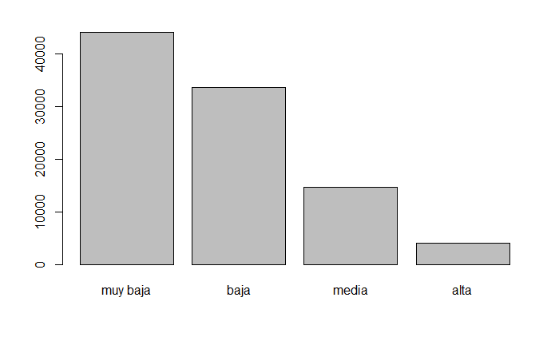

```r
df_tweets_tot$cat_difusion_RT <- cut(df_tweets_tot$difusion_RTlog10, c(-Inf,0.7, 1.7, 2.7, Inf), labels = c("muy baja", "baja", "media", "alta"))
barplot(table(df_tweets_tot$cat_difusion_RT))
```

#2 adhesion #se agrega una columna on el valor de log10

```r
df_tweets_tot$adhesion_RTlog10 = log10(df_tweets_tot$adhesion_RT + 0.0001 )
```

#histogramas de analisis

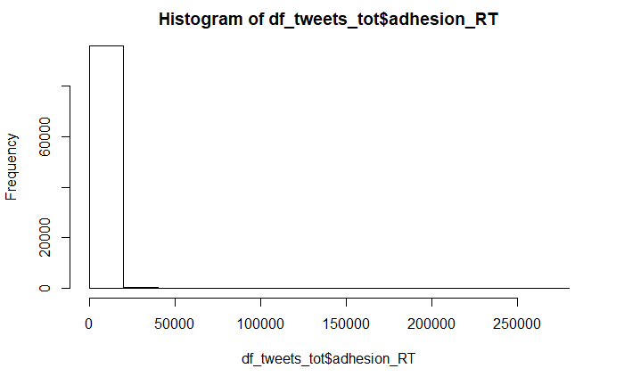

```r
hist(df_tweets_tot$adhesion_RT)
```

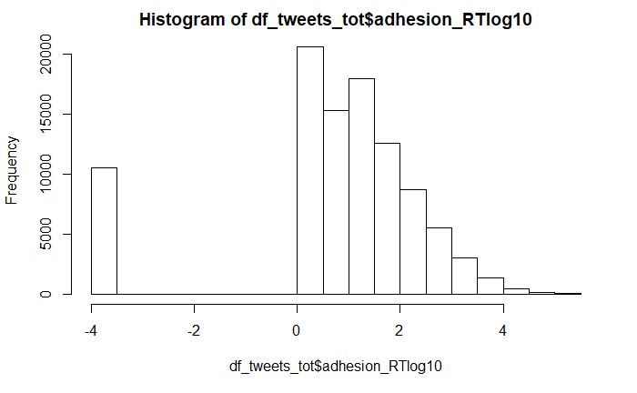

```r
hist(df_tweets_tot$adhesion_RTlog10)
```

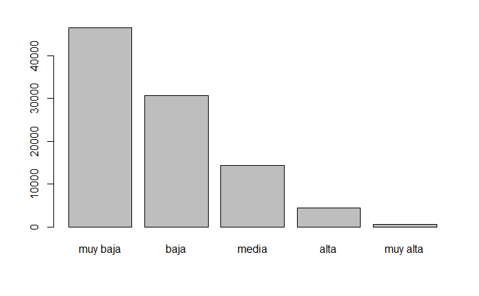

```r
df_tweets_tot$cat_adhesion_RT <- cut(df_tweets_tot$adhesion_RTlog10, c(-Inf, 1, 2, 3, 4, Inf), labels = c("muy baja", "baja", "media", "alta", "muy alta"))

barplot(table(df_tweets_tot$cat_adhesion_RT))
```

#3 primera rpta #se agrega una columna on el valor de log10

```r
df_tweets_tot$tiempo_primera_rpta_RT_minlog10 = log10(df_tweets_tot$tiempo_primera_rpta_RT_min)
```

#histogramas de analisis

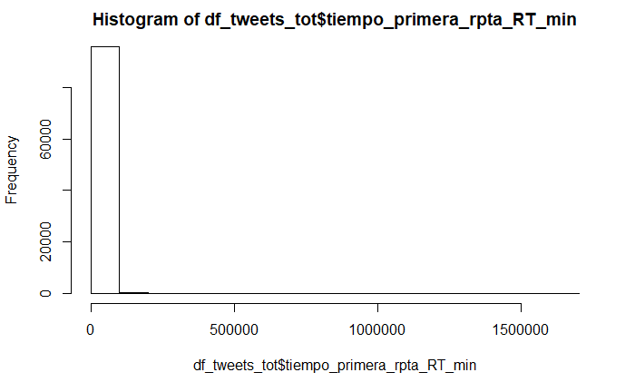

```r
hist(df_tweets_tot$tiempo_primera_rpta_RT_min)
```

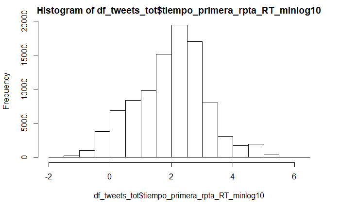

```r
hist(df_tweets_tot$tiempo_primera_rpta_RT_minlog10)
```

#categorias de primera respuesta

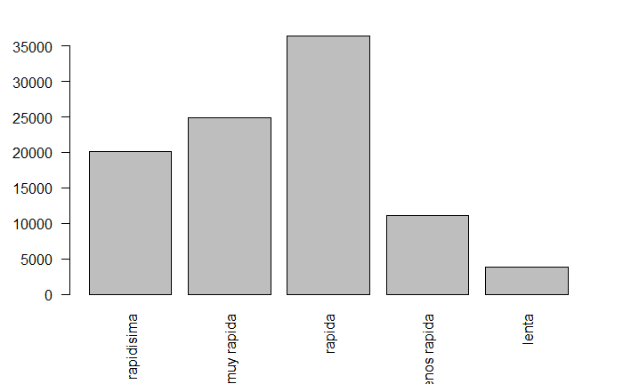

```r
df_tweets_tot$cat_rpta <- cut(df_tweets_tot$tiempo_primera_rpta_RT_minlog10, c(-Inf,1, 2, 3, 4, Inf),labels = c("rapidisima","muy rapida", "rapida", "menos rapida", "lenta"))
barplot(table(df_tweets_tot$cat_rpta), las=2)
```

#4- actividad #se calcula el cociente entre la cantidad de RT sobre la duracion del RT (Ultimo RT menos primer RT) –> Actividad #se agrega una columna on el valor de log10

```r
df_tweets_tot$actividad = df_tweets_tot$cant_RT/(df_tweets_tot$duracion_RT_min + 0.0001)

df_tweets_tot$actividadlog10 = log10(df_tweets_tot$actividad)
```

#histograma de analisis

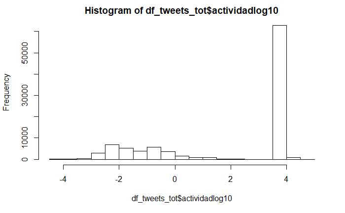

```r
hist(df_tweets_tot$actividadlog10)
```

#categorias de actividad

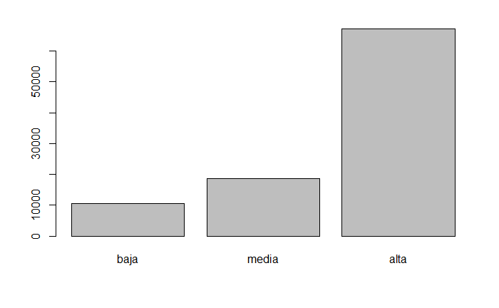

```r
df_tweets_tot$cat_actividad <- cut(df_tweets_tot$actividadlog10, c(-Inf,-2, 0, Inf), labels = c("baja", "media","alta"))

barplot(table(df_tweets_tot$cat_actividad))
```

#5 anio de creacion de la cuenta del usuario que RT #se obtiene el anio para cada usuario que RT y se guarda en un nueva columna

```r
fecha_creacion_cuenta <- as.Date(df_tweets$account_created_at)
class(fecha_creacion_cuenta)
```

```
[1] "Date"
```

```r
year_creacion_cuenta <- as.numeric(format(fecha_creacion_cuenta, "%Y"))
df_tweets$created_at_year <- year_creacion_cuenta
```

#preprocesamiento para obtener una dataset , en el cual las filas son los tweets y las columnas los anios #por cada tweet se identifica el anio de creacion de la cuenta del usuario y se completa con 1 en la columna correspondiente del anio #un tweet puede ser RT por cuentas creadas en el mismo anio, en este caso se completa una sola vez con 1 #si un anio no se enuentra entre los anios de la creacion de las cuentas se completa con 0

```r
stringsqlb = "select retweet_status_id , (CASE WHEN created_at_year = 2006 THEN 1 else 0 end) AS ANIO2006,(CASE WHEN created_at_year = 2007 THEN 1 else 0 end) AS ANIO2007, (CASE WHEN created_at_year = 2008 THEN 1 else 0 end) AS ANIO2008,(CASE WHEN created_at_year = 2009 THEN 1 else 0 end) AS ANIO2009, (CASE WHEN created_at_year = 2010 THEN 1 else 0 end) AS ANIO2010, (CASE WHEN created_at_year = 2011 THEN 1 else 0 end) AS ANIO2011, (CASE WHEN created_at_year = 2012 THEN 1 else 0 end) AS ANIO2012, (CASE WHEN created_at_year = 2013 THEN 1 else 0 end) AS ANIO2013, (CASE WHEN created_at_year = 2014 THEN 1 else 0 end) AS ANIO2014, (CASE WHEN created_at_year = 2015 THEN 1 else 0 end) AS ANIO2015, (CASE WHEN created_at_year = 2016 THEN 1 else 0 end) AS ANIO2016,(CASE WHEN created_at_year = 2017 THEN 1 else 0 end) AS ANIO2017, (CASE WHEN created_at_year = 2018 THEN 1 else 0 end) AS ANIO2018,(CASE WHEN created_at_year = 2019 THEN 1 else 0 end) AS ANIO2019, (CASE WHEN created_at_year = 2020 THEN 1 else 0 end) AS ANIO2020 from df_tweets"


df_tweets_fechas = sqldf(stringsqlb)
nrow(df_tweets_fechas)
```

```
[1] 327961
```

#se agrupa el resultado anterior por tweet y se suman los valores por columna de anio

```r
stringsqld = "select retweet_status_id ,sum(ANIO2006), sum(ANIO2007),sum(ANIO2008), sum(ANIO2009), sum(ANIO2010),sum(ANIO2011), sum(ANIO2012),sum(ANIO2013), sum(ANIO2014),sum(ANIO2015), sum(ANIO2016), sum(ANIO2017),  sum(ANIO2018), sum(ANIO2019),sum(ANIO2020)  from df_tweets_fechas group by retweet_status_id"

df_tweets_fechas1 = sqldf(stringsqld)
nrow(df_tweets_fechas1)
```

```
[1] 96388
```

#categorias de los anios –> “Si” si en el resultado anterior la suma es mayor a 0 y “na” en caso contrario

```r
df_tweets_fechas1$cat_2006= as.factor(ifelse(df_tweets_fechas1$`sum(ANIO2006)` > 0, "SI", NA))
df_tweets_fechas1$cat_2007= as.factor(ifelse(df_tweets_fechas1$`sum(ANIO2007)` > 0, "SI", NA))
df_tweets_fechas1$cat_2008= as.factor(ifelse(df_tweets_fechas1$`sum(ANIO2008)` > 0, "SI", NA))
df_tweets_fechas1$cat_2009= as.factor(ifelse(df_tweets_fechas1$`sum(ANIO2009)` > 0, "SI", NA))
df_tweets_fechas1$cat_2010= as.factor(ifelse(df_tweets_fechas1$`sum(ANIO2010)` > 0, "SI", NA))
df_tweets_fechas1$cat_2011= as.factor(ifelse(df_tweets_fechas1$`sum(ANIO2011)` > 0, "SI", NA))
df_tweets_fechas1$cat_2012= as.factor(ifelse(df_tweets_fechas1$`sum(ANIO2012)` > 0, "SI", NA))
df_tweets_fechas1$cat_2013= as.factor(ifelse(df_tweets_fechas1$`sum(ANIO2013)` > 0, "SI", NA))
df_tweets_fechas1$cat_2014= as.factor(ifelse(df_tweets_fechas1$`sum(ANIO2014)` > 0, "SI", NA))
df_tweets_fechas1$cat_2015= as.factor(ifelse(df_tweets_fechas1$`sum(ANIO2015)` > 0, "SI", NA))
df_tweets_fechas1$cat_2016= as.factor(ifelse(df_tweets_fechas1$`sum(ANIO2016)` > 0, "SI", NA))
df_tweets_fechas1$cat_2017= as.factor(ifelse(df_tweets_fechas1$`sum(ANIO2017)` > 0, "SI", NA))
df_tweets_fechas1$cat_2018= as.factor(ifelse(df_tweets_fechas1$`sum(ANIO2018)` > 0, "SI", NA))
df_tweets_fechas1$cat_2019= as.factor(ifelse(df_tweets_fechas1$`sum(ANIO2019)` > 0, "SI", NA))
df_tweets_fechas1$cat_2020= as.factor(ifelse(df_tweets_fechas1$`sum(ANIO2020)` > 0, "SI", NA))
```

#se unen los dataset de anios con el de las otras categorias

```r
df_tweets_cat = cbind(df_tweets_tot,df_tweets_fechas1)
```

# generación de reglas

```r
trans <- as(df_tweets_cat[c("cat_actividad","cat_rpta", "cat_difusion_RT", "cat_adhesion_RT","cat_2006","cat_2007","cat_2008","cat_2009","cat_2010","cat_2011","cat_2012","cat_2013","cat_2014","cat_2015","cat_2016","cat_2017","cat_2018","cat_2019","cat_2020")], "transactions")


summary(trans)
```

```
transactions as itemMatrix in sparse format with
 96388 rows (elements/itemsets/transactions) and
 32 columns (items) and a density of 0.183767

most frequent items:
      cat_actividad=alta cat_adhesion_RT=muy baja cat_difusion_RT=muy baja          cat_rpta=rapida     cat_difusion_RT=baja
                   67242                    46553                    44055                    36431                    33599
                 (Other)
                  338934

element (itemset/transaction) length distribution:
sizes
    5     6     7     8     9    10    11    12    13    14    15    16    17    18
65796 13957  5966  3198  1983  1343   938   735   626   551   480   603   185    27

   Min. 1st Qu.  Median    Mean 3rd Qu.    Max.
  5.000   5.000   5.000   5.881   6.000  18.000

includes extended item information - examples:
```

|  | labels | variables | levels |
| --- | --- | --- | --- |
| 1 | cat_actividad=baja | cat_actividad | baja |
| 2 | cat_actividad=media | cat_actividad | media |
| 3 | cat_actividad=alta | cat_actividad | alta |

```
includes extended transaction information - examples:
```

|  | transactionID |
| --- | --- |
| 1 | 1 |
| 2 | 2 |
| 3 | 3 |

```r
rules = apriori(trans, parameter=list(target="rule", support=0.002, confidence=0.6,  minlen=2))
```

```
Apriori

Parameter specification:
```

|  | confidence | minval | smax | arem | aval | originalSupport | maxtime | support | minlen | maxlen | target | ext |
| --- | --- | --- | --- | --- | --- | --- | --- | --- | --- | --- | --- | --- |
|  | 0.6 | 0.1 | 1 | none | FALSE | TRUE | 5 | 0.002 | 2 | 10 | rules | TRUE |

```
Algorithmic control:
```

|  | filter | tree | heap | memopt | load | sort | verbose |
| --- | --- | --- | --- | --- | --- | --- | --- |
|  | 0.1 | TRUE | TRUE | FALSE | TRUE | 2 | TRUE |

```
Absolute minimum support count: 192

set item appearances ...[0 item(s)] done [0.02s].
set transactions ...[32 item(s), 96388 transaction(s)] done [0.05s].
sorting and recoding items ... [31 item(s)] done [0.01s].
creating transaction tree ... done [0.05s].
checking subsets of size 1 2 3 4 5 6 7 8 9 10
```

```
Mining stopped (maxlen reached). Only patterns up to a length of 10 returned!
```

```
 done [0.43s].
writing ... [801193 rule(s)] done [0.80s].
creating S4 object  ... done [0.34s].
```

```r
print(rules)
```

```
set of 801193 rules
```

#analisis de reglas

```r
difusion_rules = subset(rules, subset =  (lhs %pin% "cat_actividad=alta") & (lift > 1) & (rhs %pin% "alta"))
print(difusion_rules)
```

```
set of 15 rules
```

```r
inspect(sort(difusion_rules, by="lift", decreasing = TRUE))
```

```
     lhs                           rhs                        support confidence    coverage     lift count
[1]  {cat_actividad=alta,
      cat_adhesion_RT=muy alta} => {cat_difusion_RT=alta} 0.002562560  0.9762846 0.002624808 23.42597   247
[2]  {cat_actividad=alta,
      cat_adhesion_RT=alta,
      cat_2010=SI}              => {cat_difusion_RT=alta} 0.002790804  0.7451524 0.003745279 17.87995   269
[3]  {cat_actividad=alta,
      cat_adhesion_RT=alta,
      cat_2011=SI}              => {cat_difusion_RT=alta} 0.002863427  0.7282322 0.003932025 17.47395   276
[4]  {cat_actividad=alta,
      cat_rpta=rapida,
      cat_difusion_RT=alta}     => {cat_adhesion_RT=alta} 0.006266340  0.7793548 0.008040420 17.26510   604
[5]  {cat_actividad=alta,
      cat_rpta=menos rapida,
      cat_adhesion_RT=alta}     => {cat_difusion_RT=alta} 0.005021372  0.7014493 0.007158567 16.83129   484
[6]  {cat_actividad=alta,
      cat_difusion_RT=alta,
      cat_2010=SI}              => {cat_adhesion_RT=alta} 0.002790804  0.7535014 0.003703781 16.69237   269
[7]  {cat_actividad=alta,
      cat_difusion_RT=alta,
      cat_2011=SI}              => {cat_adhesion_RT=alta} 0.002863427  0.7479675 0.003828277 16.56977   276
[8]  {cat_actividad=alta,
      cat_rpta=menos rapida,
      cat_difusion_RT=alta}     => {cat_adhesion_RT=alta} 0.005021372  0.7366819 0.006816201 16.31976   484
[9]  {cat_actividad=alta,
      cat_difusion_RT=alta}     => {cat_adhesion_RT=alta} 0.014545379  0.7223081 0.020137361 16.00134  1402
[10] {cat_actividad=alta,
      cat_rpta=rapida,
      cat_adhesion_RT=alta}     => {cat_difusion_RT=alta} 0.006266340  0.6586696 0.009513632 15.80479   604
[11] {cat_actividad=alta,
      cat_difusion_RT=alta,
      cat_2019=SI}              => {cat_adhesion_RT=alta} 0.002375814  0.7111801 0.003340665 15.75482   229
[12] {cat_actividad=alta,
      cat_adhesion_RT=alta}     => {cat_difusion_RT=alta} 0.014545379  0.6323861 0.023000788 15.17412  1402
[13] {cat_actividad=alta,
      cat_difusion_RT=alta,
      cat_2020=SI}              => {cat_adhesion_RT=alta} 0.002261692  0.6546547 0.003454787 14.50261   218
[14] {cat_actividad=alta,
      cat_adhesion_RT=alta,
      cat_2020=SI}              => {cat_difusion_RT=alta} 0.002261692  0.6038781 0.003745279 14.49007   218
[15] {cat_actividad=alta,
      cat_rpta=lenta,
      cat_difusion_RT=alta}     => {cat_adhesion_RT=alta} 0.002987924  0.6012526 0.004969498 13.31959   288
```

```r
difusion_rules = subset(rules, subset = (lhs %pin% "rapida") & (lift > 18) & (rhs %pin% "alta"))

print(difusion_rules)
```

```
set of 2570 rules
```

```r
inspect(head(difusion_rules, 20))
```

```
     lhs                       rhs                        support confidence    coverage     lift count
[1]  {cat_actividad=baja,
      cat_rpta=rapida,
      cat_adhesion_RT=alta} => {cat_difusion_RT=alta} 0.003506661  0.7842227 0.004471511 18.81744   338
[2]  {cat_rpta=rapida,
      cat_adhesion_RT=alta,
      cat_2009=SI}          => {cat_difusion_RT=alta} 0.003963149  0.7655311 0.005176993 18.36893   382
[3]  {cat_rpta=rapida,
      cat_adhesion_RT=alta,
      cat_2009=SI,
      cat_2016=SI}          => {cat_difusion_RT=alta} 0.002489937  0.8000000 0.003112421 19.19602   240
[4]  {cat_rpta=rapida,
      cat_adhesion_RT=alta,
      cat_2009=SI,
      cat_2015=SI}          => {cat_difusion_RT=alta} 0.002510686  0.8093645 0.003102046 19.42072   242
[5]  {cat_rpta=rapida,
      cat_adhesion_RT=alta,
      cat_2009=SI,
      cat_2017=SI}          => {cat_difusion_RT=alta} 0.002531435  0.8187919 0.003091671 19.64693   244
[6]  {cat_rpta=rapida,
      cat_adhesion_RT=alta,
      cat_2009=SI,
      cat_2014=SI}          => {cat_difusion_RT=alta} 0.002666307  0.8107256 0.003288791 19.45338   257
[7]  {cat_rpta=rapida,
      cat_adhesion_RT=alta,
      cat_2009=SI,
      cat_2018=SI}          => {cat_difusion_RT=alta} 0.002510686  0.7934426 0.003164294 19.03867   242
[8]  {cat_rpta=rapida,
      cat_adhesion_RT=alta,
      cat_2009=SI,
      cat_2013=SI}          => {cat_difusion_RT=alta} 0.002759680  0.8085106 0.003413288 19.40023   266
[9]  {cat_rpta=rapida,
      cat_adhesion_RT=alta,
      cat_2009=SI,
      cat_2012=SI}          => {cat_difusion_RT=alta} 0.002749305  0.7658960 0.003589658 18.37769   265
[10] {cat_rpta=rapida,
      cat_adhesion_RT=alta,
      cat_2009=SI,
      cat_2020=SI}          => {cat_difusion_RT=alta} 0.002687056  0.7872340 0.003413288 18.88970   259
[11] {cat_rpta=rapida,
```

[output cut: 24 more lines]

```
      cat_adhesion_RT=alta,
      cat_2014=SI,
      cat_2016=SI}          => {cat_difusion_RT=alta} 0.002853052  0.7746479 0.003683031 18.58769   275
[18] {cat_rpta=rapida,
      cat_adhesion_RT=alta,
      cat_2016=SI,
      cat_2018=SI}          => {cat_difusion_RT=alta} 0.002728555  0.7712610 0.003537785 18.50642   263
[19] {cat_rpta=rapida,
      cat_adhesion_RT=alta,
      cat_2013=SI,
      cat_2016=SI}          => {cat_difusion_RT=alta} 0.002873802  0.7589041 0.003786778 18.20992   277
[20] {cat_rpta=rapida,
      cat_adhesion_RT=alta,
      cat_2012=SI,
      cat_2016=SI}          => {cat_difusion_RT=alta} 0.002946425  0.7634409 0.003859402 18.31878   284
```